# R 탐색적 자료분석

연규필

#### 학습목표: R을 활용한 탐색적 자료분석을 수행하여 R 활용력을 키운다.

# 1 . 데이터셋 불러오기

```r
talent = read.csv("data/actors.csv", stringsAsFactors = TRUE)
talent
```

```
##      name gender  ht  wt bld
## 1  소지섭      M 182  70   O
## 2  조인성      M 186  72   B
## 3    현빈      M 184  74   B
## 4  김태희      F 165  45   O
## 5  송혜교      F 164  45   A
## 6  김아중      F 170  48   A
## 7  성시경      M 186  80   A
## 8  이효리      F 163  52   A
## 9  강동원      M 186  68   B
## 10 차승원      M 188  80   B
## 11 전지현      F 172  48   B
## 12 이수근      M  NA  62   O
## 13 윤은혜      F 167  52   O
## 14 강호동      M 182 115   O
## 15 공효진      F 172  48   A
## 16 한석규      M 178  68  AB
## 17 유재석      M 178  65   O
## 18   원빈      M 178  63   O
```

# 2 . 데이터셋 살펴보기

## 2.1 데이터 구조

### 2.1.1 행과 열의 갯수

```r
dim(talent)
```

```
## [1] 18  5
```

### 2.1.2 데이터 Structure

```r
str(talent)
```

[output not shown]

```r
#install.packages("tibble")
library(tibble)
glimpse(talent)
```

```
## Observations: 18
## Variables: 5
## $ name   <fct> 소지섭, 조인성, 현빈, 김태희, 송혜교, 김아중, 성시경, 이효리, 강동원, 차승원, 전지현, 이...
## $ gender <fct> M, M, M, F, F, F, M, F, M, M, F, M, F, M, F, M, M, M
## $ ht     <int> 182, 186, 184, 165, 164, 170, 186, 163, 186, 188, 172, ...
## $ wt     <int> 70, 72, 74, 45, 45, 48, 80, 52, 68, 80, 48, 62, 52, 115...
## $ bld    <fct> O, B, B, O, A, A, A, A, B, B, B, O, O, O, A, AB, O, O
```

### 2.1.3 처음 여섯 개체

```r
head(talent)
```

```
##     name gender  ht wt bld
## 1 소지섭      M 182 70   O
## 2 조인성      M 186 72   B
## 3   현빈      M 184 74   B
## 4 김태희      F 165 45   O
## 5 송혜교      F 164 45   A
## 6 김아중      F 170 48   A
```

### 2.1.4 마지막 여섯 개체

```r
tail(talent)
```

```
##      name gender  ht  wt bld
## 13 윤은혜      F 167  52   O
## 14 강호동      M 182 115   O
## 15 공효진      F 172  48   A
## 16 한석규      M 178  68  AB
## 17 유재석      M 178  65   O
## 18   원빈      M 178  63   O
```

### 2.1.5 변수명 확인

```r
names(talent)
```

```
## [1] "name"   "gender" "ht"     "wt"     "bld"
```

### 2.1.6 결측치 여부

```r
is.na(talent)
```

```
##        name gender    ht    wt   bld
##  [1,] FALSE  FALSE FALSE FALSE FALSE
##  [2,] FALSE  FALSE FALSE FALSE FALSE
##  [3,] FALSE  FALSE FALSE FALSE FALSE
##  [4,] FALSE  FALSE FALSE FALSE FALSE
##  [5,] FALSE  FALSE FALSE FALSE FALSE
##  [6,] FALSE  FALSE FALSE FALSE FALSE
##  [7,] FALSE  FALSE FALSE FALSE FALSE
##  [8,] FALSE  FALSE FALSE FALSE FALSE
##  [9,] FALSE  FALSE FALSE FALSE FALSE
## [10,] FALSE  FALSE FALSE FALSE FALSE
## [11,] FALSE  FALSE FALSE FALSE FALSE
## [12,] FALSE  FALSE  TRUE FALSE FALSE
## [13,] FALSE  FALSE FALSE FALSE FALSE
## [14,] FALSE  FALSE FALSE FALSE FALSE
## [15,] FALSE  FALSE FALSE FALSE FALSE
## [16,] FALSE  FALSE FALSE FALSE FALSE
## [17,] FALSE  FALSE FALSE FALSE FALSE
## [18,] FALSE  FALSE FALSE FALSE FALSE
```

```r
any(is.na(talent))
```

```
## [1] TRUE
```

```r
sum(is.na(talent))
```

```
## [1] 1
```

# 3 . 간단한 기술통계

## 3.1 연속형 변수 분석

- 특정 데이터셋의 변수를 접근할 때는 [**dataset이름$variable이름**] 형태를 이용
- 한줄에 여러 명령어를 입력시 세미콜론(;)으로 구분
- na.rm=TRUE 또는 na.rm=T 옵션은 결측치를 빼고 분석한다.

```r
mean(talent$ht, na.rm=TRUE)
```

```
## [1] 176.5294
```

```r
max(talent$ht, na.rm=TRUE)
```

```
## [1] 188
```

```r
min(talent$ht)
```

```
## [1] NA
```

```r
median(talent$ht, na.rm=TRUE)
```

```
## [1] 178
```

```r
var(talent$ht, na.rm=TRUE)
```

```
## [1] 73.13971
```

```r
sd(talent$ht, na.rm=TRUE)
```

```
## [1] 8.552176
```

```r
summary(talent$ht)
```

```
##    Min. 1st Qu.  Median    Mean 3rd Qu.    Max.    NA's
##   163.0   170.0   178.0   176.5   184.0   188.0       1
```

## 3.2 범주형 변수 분석

```r
table(talent$gender)
```

```
##
##  F  M
##  7 11
```

```r
table(talent$bld)
```

```
##
##  A AB  B  O
##  5  1  5  7
```

```r
table(talent$gender, talent$bld)
```

```
##
##     A AB B O
##   F 4  0 1 2
##   M 1  1 4 5
```

```r
table(talent$bld, talent$gender)
```

```
##
##      F M
##   A  4 1
##   AB 0 1
##   B  1 4
##   O  2 5
```

## 3.3 Graph

### 3.3.1 Histogram

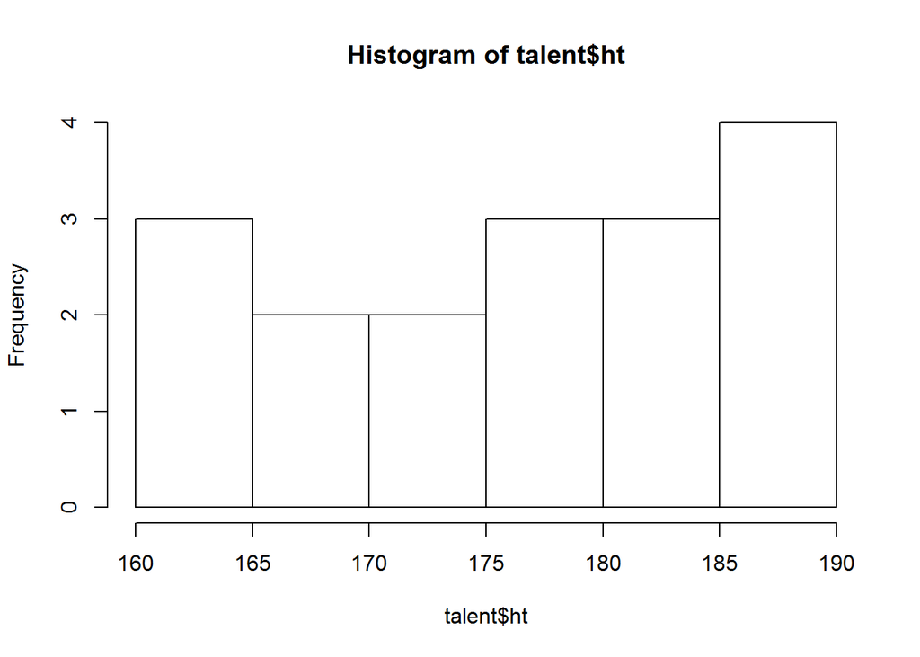

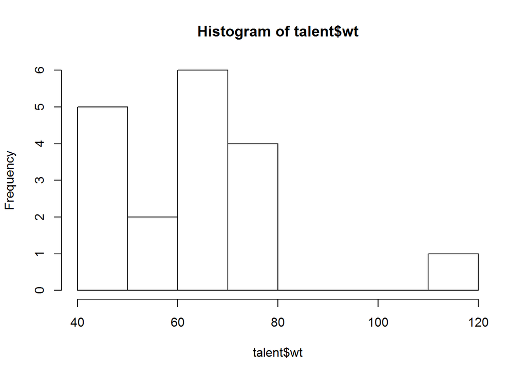

```r
hist(talent$ht); hist(talent$wt)
```

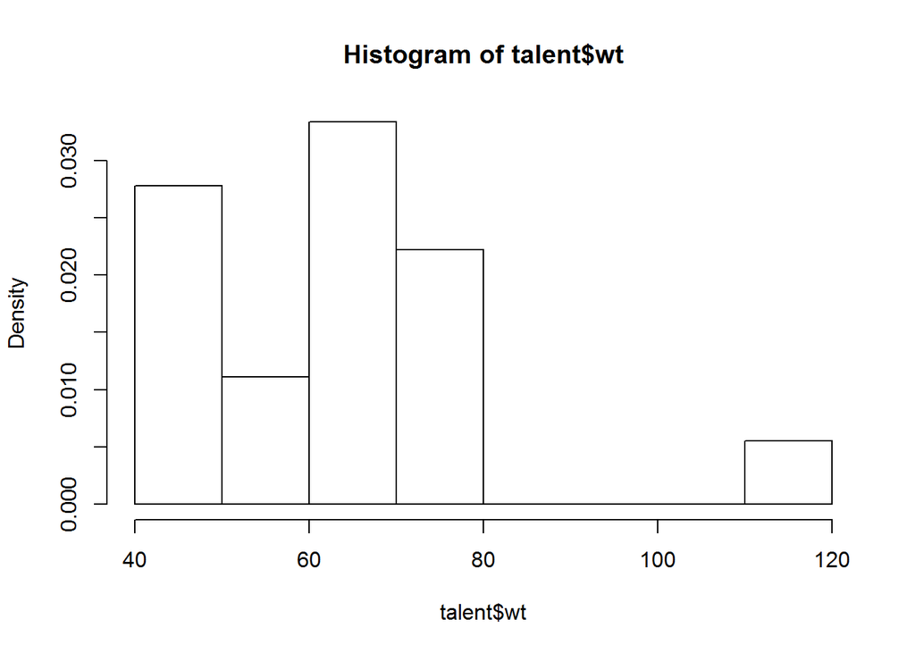

```r
hist(talent$wt, prob=T)
```

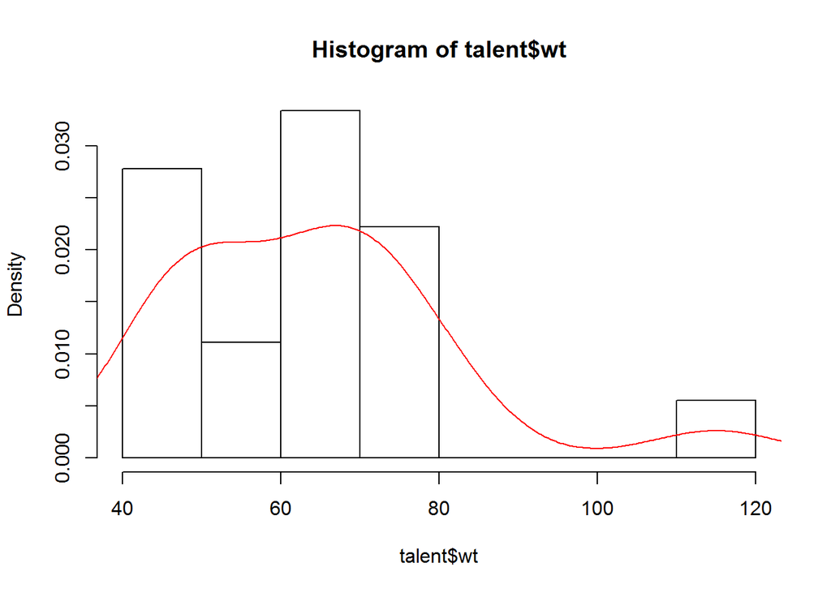

```r
hist(talent$wt, prob=T)
lines(density(talent$wt), col="red")
```

### 3.3.2 Boxplot

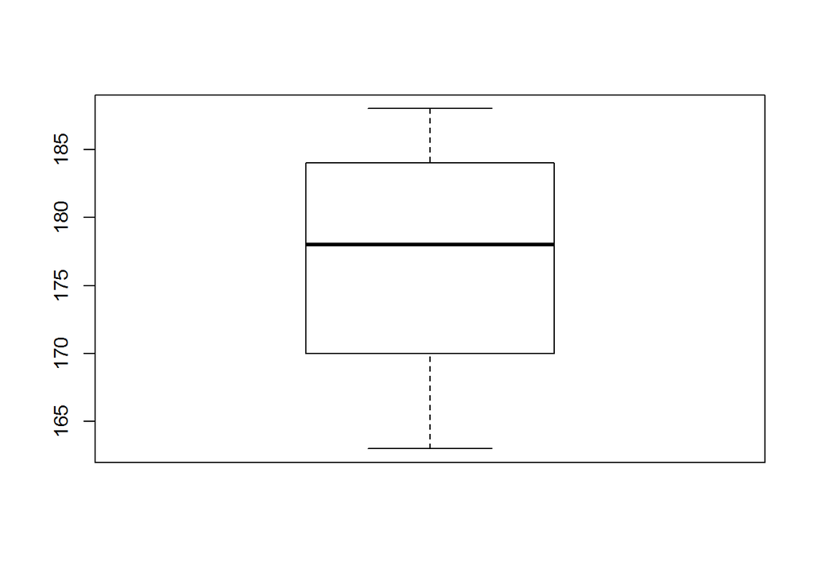

```r
boxplot(talent$ht)
```

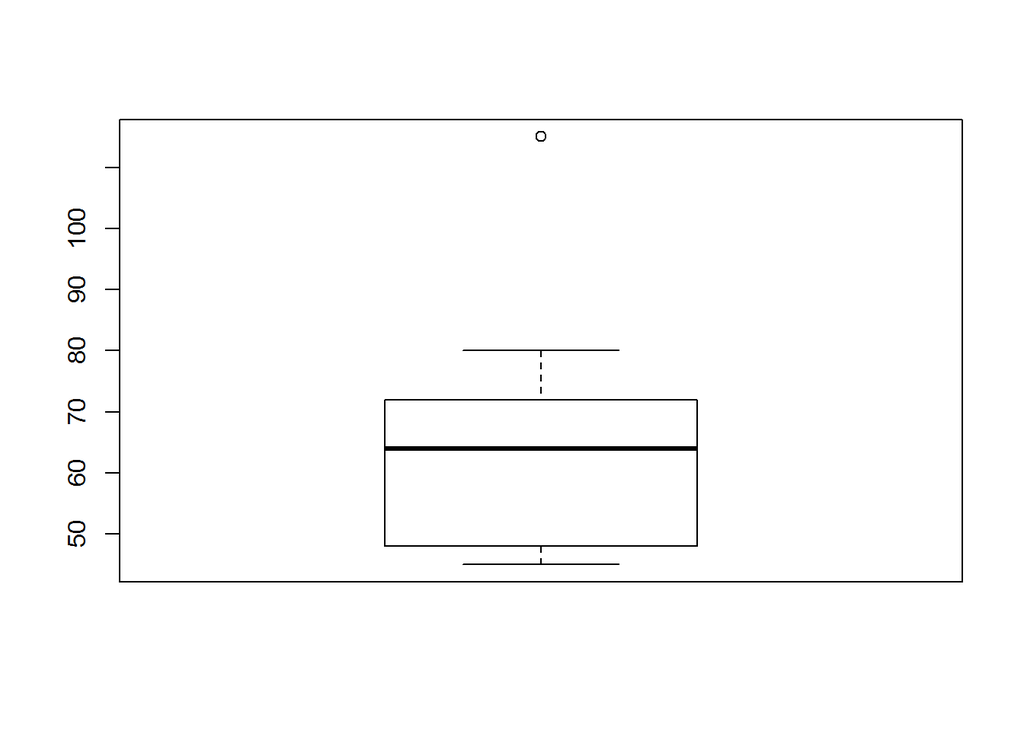

```r
boxplot(talent$wt)
```

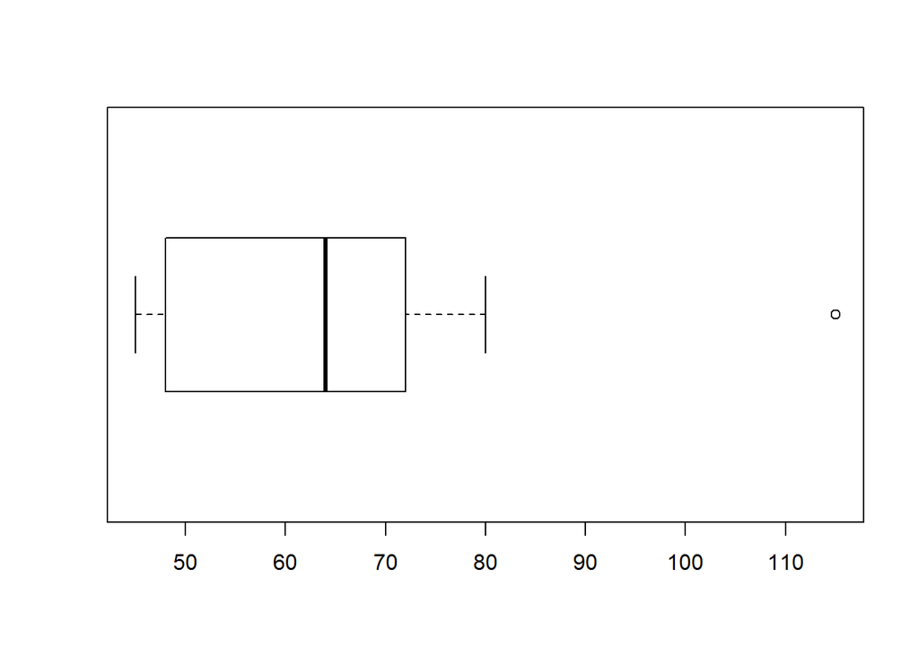

```r
boxplot(talent$wt, horizontal=TRUE)
```

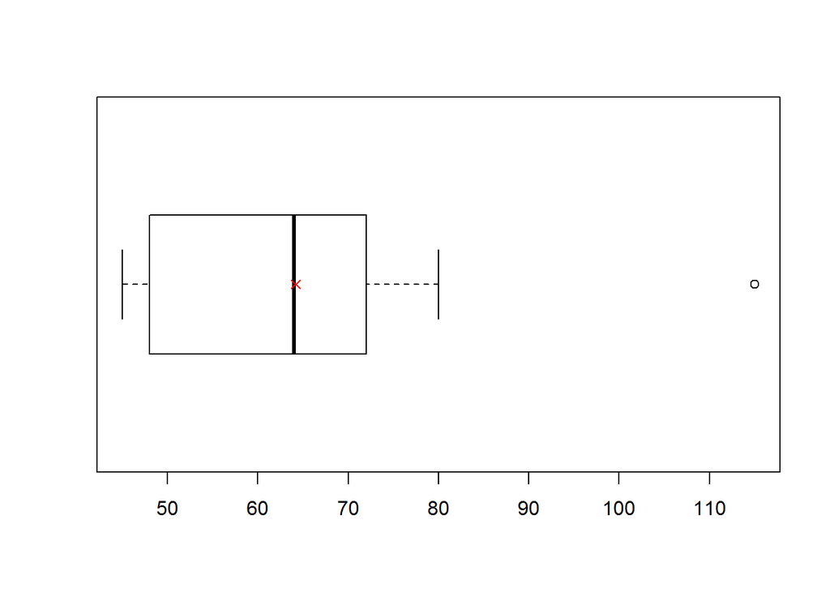

```r
boxplot(talent$wt, horizontal=TRUE)
mean.wt = round(mean(talent$wt),2)
points(mean.wt, 1, pch=4, col="red") #평균표
```

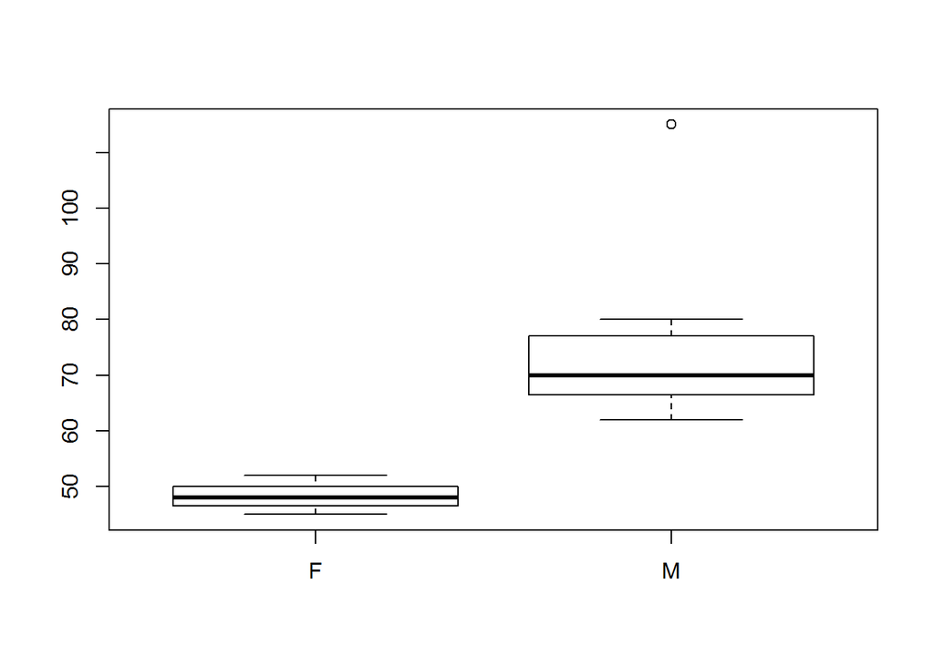

```r
boxplot(wt~gender, data=talent)
```

### 3.3.3 산점도

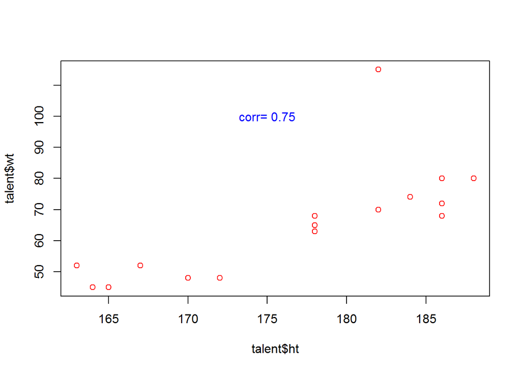

```r
plot(talent$ht, talent$wt, col="red")
cor.hw=round(cor(talent$ht, talent$wt, use = "complete.obs"), 2)
text(175,100, labels=paste("corr=",cor.hw), col="blue")
```

### 3.3.4 Bar plot

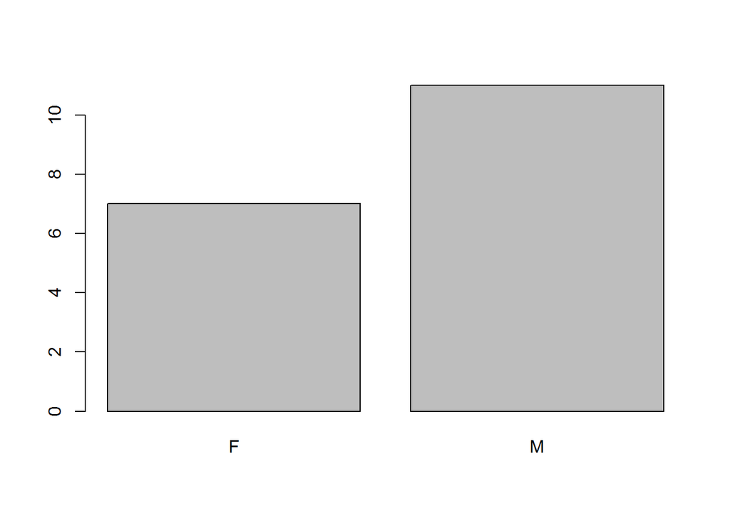

```r
barplot(table(talent$gender))
```

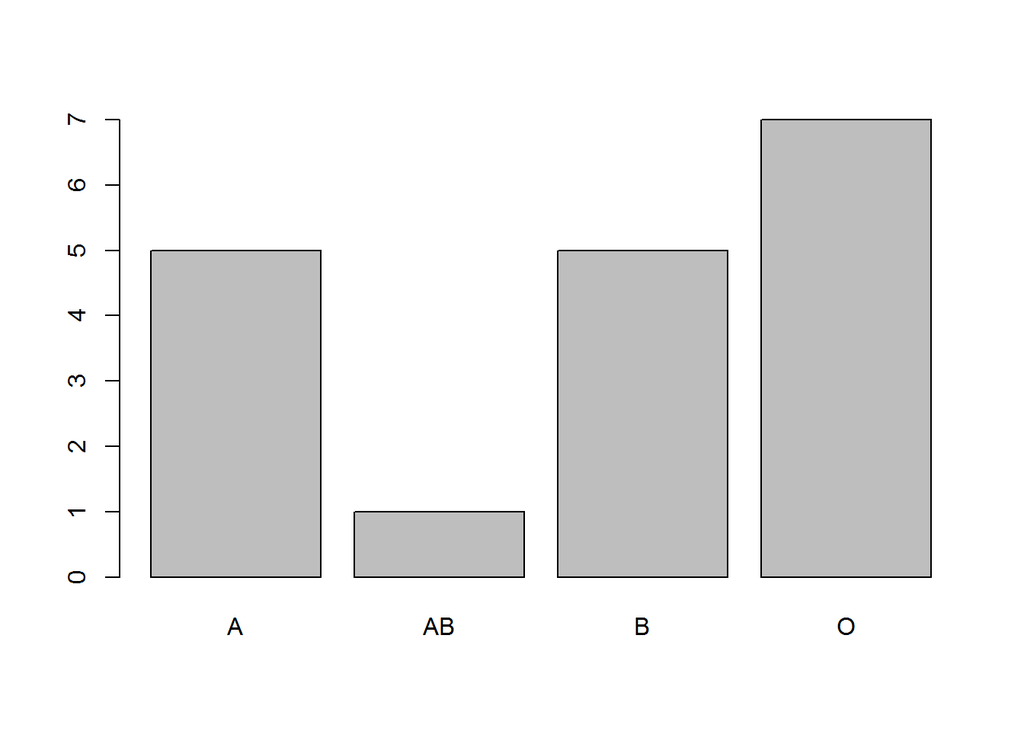

```r
barplot(table(talent$bld))
```

# 4 . 가설검정

## 4.1 성별 몸무게 차이

남자의 몸무게는 여자보다 평균 15kg 이상이라고 할 수 있는가?

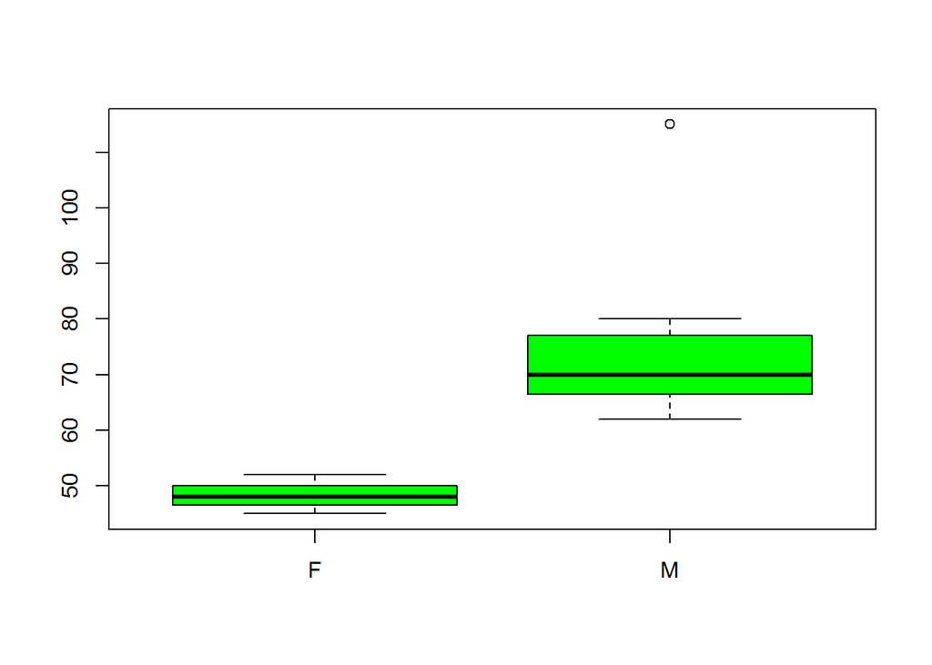

```r
boxplot(wt~gender, data=talent, col="green")
```

```r
levels(talent$gender)
```

```
## [1] "F" "M"
```

```r
talent$gender=relevel(talent$gender, "M")
```

```r
levels(talent$gender)
```

```
## [1] "M" "F"
```

```r
t.test(wt~gender, data=talent, alternative="greater", mu=15, var.equal=TRUE)
```

```
##
##  Two Sample t-test
##
## data:  wt by gender
## t = 1.9207, df = 16, p-value = 0.03639
## alternative hypothesis: true difference in means is greater than 15
## 95 percent confidence interval:
##  16.00007      Inf
## sample estimates:
## mean in group M mean in group F
##        74.27273        48.28571
```

```r
t.test(wt~gender, data=talent, alternative="greater", mu=15, var.equal=FALSE)
```

```
##
##  Welch Two Sample t-test
##
## data:  wt by gender
## t = 2.3926, df = 11.152, p-value = 0.01771
## alternative hypothesis: true difference in means is greater than 15
## 95 percent confidence interval:
##  17.75037      Inf
## sample estimates:
## mean in group M mean in group F
##        74.27273        48.28571
```

```r
var.test(wt~gender, data=talent, alternative="two.sided")
```

```
##
##  F test to compare two variances
##
## data:  wt by gender
## F = 26.586, num df = 10, denom df = 6, p-value = 0.000704
## alternative hypothesis: true ratio of variances is not equal to 1
## 95 percent confidence interval:
##    4.868055 108.261773
## sample estimates:
## ratio of variances
##           26.58602
```

# 5 . 단순회귀분석

```r
fit=lm(wt~ht, data=talent)
summary(fit)
```

```
##
## Call:
## lm(formula = wt ~ ht, data = talent)
##
## Residuals:
##     Min      1Q  Median      3Q     Max
## -11.058  -6.115  -1.940   0.942  42.177
##
## Coefficients:
##              Estimate Std. Error t value Pr(>|t|)
## (Intercept) -210.9086    63.6836  -3.312 0.004743 **
## ht             1.5590     0.3604   4.326 0.000599 ***
## ---
## Signif. codes:  0 '***' 0.001 '**' 0.01 '*' 0.05 '.' 0.1 ' ' 1
##
## Residual standard error: 12.33 on 15 degrees of freedom
##   (1 observation deleted due to missingness)
## Multiple R-squared:  0.5551, Adjusted R-squared:  0.5254
## F-statistic: 18.72 on 1 and 15 DF,  p-value: 0.0005994
```

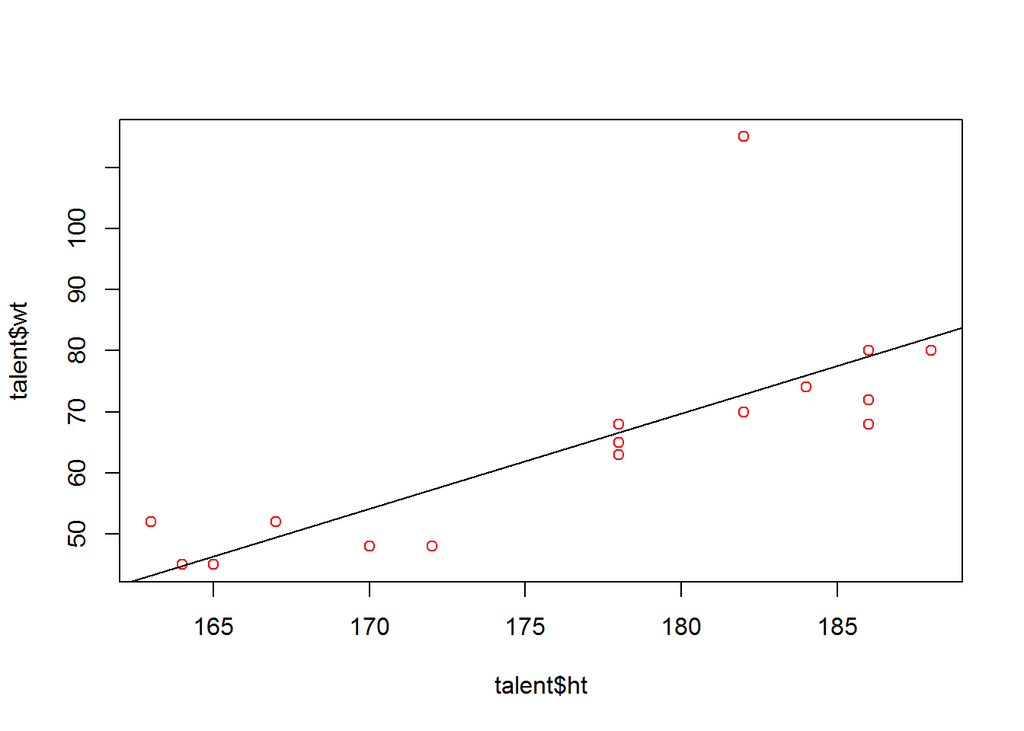

```r
a = fit$coef[1]; b = fit$coef[2]

plot(talent$ht, talent$wt, col="red")
abline(a,b)
```

# 6 . 데이터 분석 실습

#### airquality 데이터는 다음과 같은 변수들을 가지고 있다.

```r
data("airquality")
str(airquality)
```

```
## 'data.frame':    153 obs. of  6 variables:
##  $ Ozone  : int  41 36 12 18 NA 28 23 19 8 NA ...
##  $ Solar.R: int  190 118 149 313 NA NA 299 99 19 194 ...
##  $ Wind   : num  7.4 8 12.6 11.5 14.3 14.9 8.6 13.8 20.1 8.6 ...
##  $ Temp   : int  67 72 74 62 56 66 65 59 61 69 ...
##  $ Month  : int  5 5 5 5 5 5 5 5 5 5 ...
##  $ Day    : int  1 2 3 4 5 6 7 8 9 10 ...
```

#### airquality 데이터에 대하여 다음 절차에 따라 분석을 수행해보자

1. 데이터 구조 및 변수명 살펴보기
2. 결측치 탐색
3. 연속형 변수에 대한 기술통계량 및 그래프
4. Ozone과 Solar.R, Ozone과 Wind, Ozone과 Temp 간의 산점도
5. 범주형 변수에 대한 요약테이블 및 그래프 (Month와 Day를 범주형으로 간주)
6. 오존 농도와 가장 연관성이 많은 변수는 어떤 변수로 판단되는가?
7. 오존 농도는 월 또는 일별로 어떤 차이가 나타나는가?

#### Further Study

- 오존 농도와 세 변수(Solar.R, Wind, Temp) 간의 연관관계를 어떤 방법으로 도출할 수 있을까? ==> 회귀분석
- 오존 농도가 100ppb를 넘으면 눈이 따갑고 메스꺼우며 호흡기 질환이 발생한다고 한다. 위 자료에 의하면 외출을 자제해야할 시기는 언제인가?